# 4.preprocessImages

# Pre-processing images

*Started on Mon Jun 6 08:00:56 2016*

## Loading the data

We load from the compiled, preformatted data saved earlier. We also define the random seed for repeatability.

```r
set.seed(56)
load("im.train.RData")
ls()
```

```
## [1] "im.train"
```

## Current ideas

The general idea would be to reduce image dimensionality to identify where the nose or principal components of the face are, with a global approach.

Reduction could be done by :

- applying a high pass filter to detect shapes ?
- applying PCA to the images ? ** selecting a set of subimage covering evrything ? ** carefully selecting the PCA sub-image locations around eye/month/nose ? ** including images from larger, reduced precision, or sparse sub images ?

## Splitting a picture in sub-images

Since computing PCA for the full image is computionnally out of reach, lets try to compute on sub-image.

One way to do it is to select the subimage via its indices. For instance, to select the sub-image [10:20,40:50] from the im.train vector, we can just compute the indexes and apply them to the image, in vector format.

The function below generates the index in the initial vector when provided with the sequence of pixels from the sub-image.

```r
im.pca.makesubindex <- function(xseq, yseq) {
  as.vector(matrix(1:9216, nrow=96,ncol=96)[xseq,yseq])
}
```

Let’s see an example, using this to extract a 30x30 subimage.

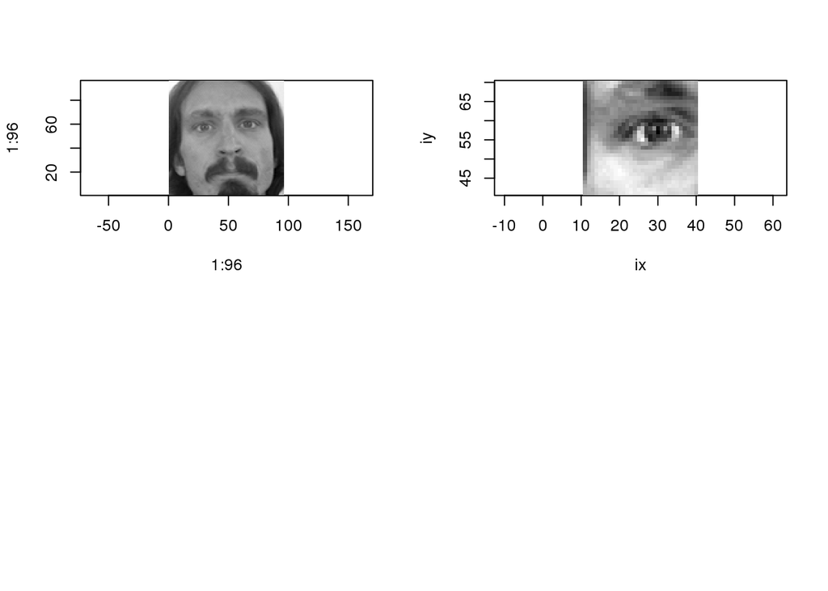

```r
i <- rev(im.train[1,])
ix <- 11:40
iy <- 41:70
ii <- i[im.pca.makesubindex(xseq = ix,yseq=iy)]
## ii is stil a vector, can be processed directly ...

par(mfrow = c(2,2))
image(1:96,1:96,matrix(i,nrow=96,ncol=96), col=gray((0:255)/255),asp=1.)
image(ix,iy, matrix(ii,nrow=length(ix),ncol=length(iy)), col=gray((0:255)/255),asp=1.)
rm(i,ii,ix,iy)
```

What if we look at the entire image, retaining 1 pixel out of 4 ? of 6 ? of 8 ?

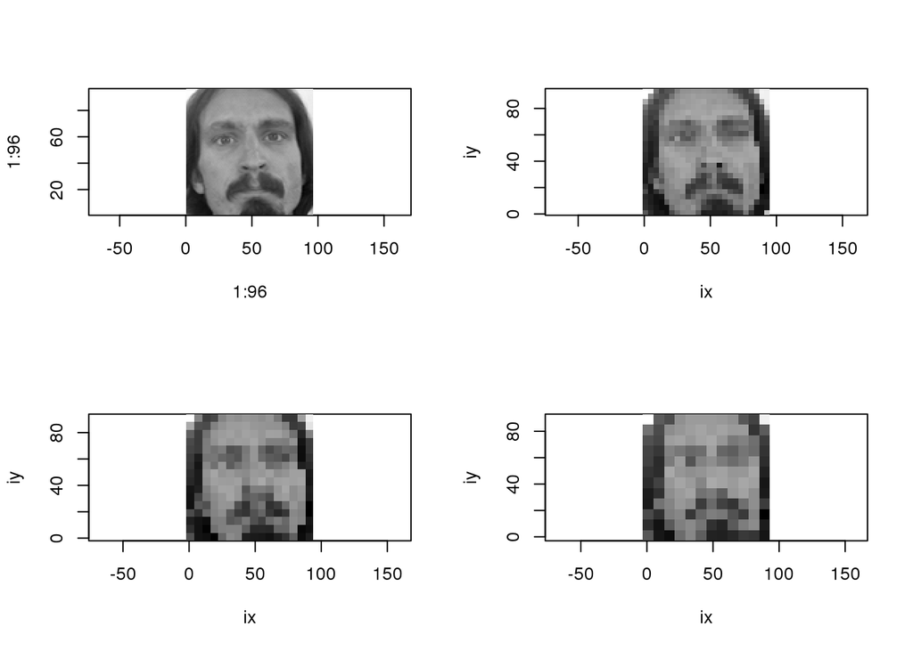

```r
i <- rev(im.train[1,])

par(mfrow = c(2,2))
image(1:96,1:96,matrix(i,nrow=96,ncol=96), col=gray((0:255)/255),asp=1.)

ix <- seq(1,96,4)
iy <- ix
ii <- i[im.pca.makesubindex(xseq = ix,yseq=iy)]
image(ix,iy, matrix(ii,nrow=length(ix),ncol=length(iy)), col=gray((0:255)/255),asp=1.)

ix <- seq(1,96,6)
iy <- ix
ii <- i[im.pca.makesubindex(xseq = ix,yseq=iy)]
image(ix,iy, matrix(ii,nrow=length(ix),ncol=length(iy)), col=gray((0:255)/255),asp=1.)

ix <- seq(1,96,8)
iy <- ix
ii <- i[im.pca.makesubindex(xseq = ix,yseq=iy)]
image(ix,iy, matrix(ii,nrow=length(ix),ncol=length(iy)), col=gray((0:255)/255),asp=1.)
```

```r
rm(i,ii,ix, iy)
```

## A first approach to PCA analysis of the images

First, focusing on approx 1000 pixels. (we have ~ 10 000 pixels/image in total). Let’s use the eye location from above.

To be investigated later :

- scaling/centering are probably a good idea. Is it really ? if yes, at the global level or subimage ?
- setting ‘tol’ to eliminate anomalies ?

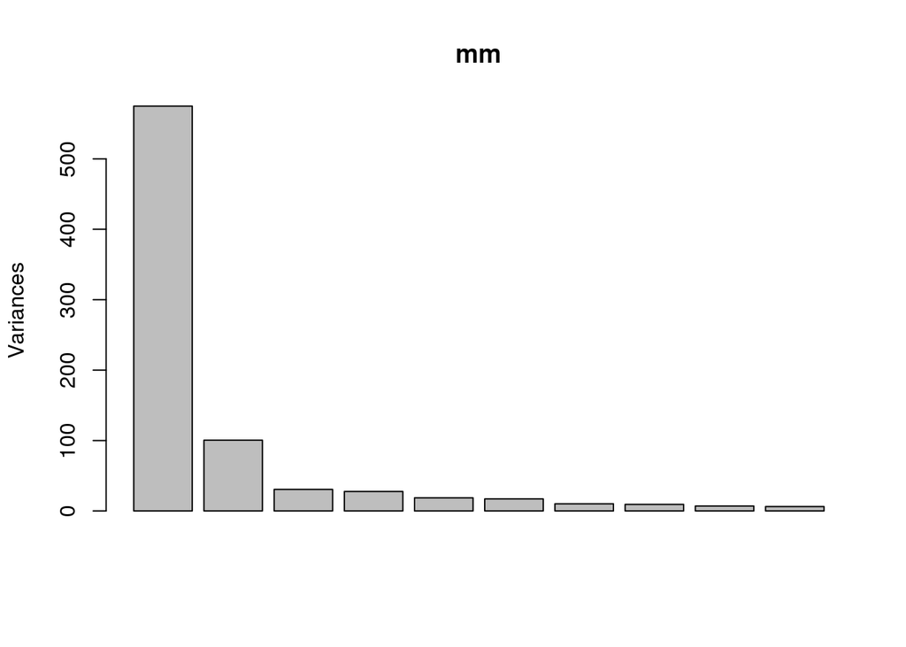

```r
mm <- prcomp(im.train[,im.pca.makesubindex(xseq=11:40,yseq=41:70)],scale. = TRUE, center=TRUE, retx = FALSE )

plot(mm)
```

```r
rm(mm)
```

## Compressing the full image

Now, what we want to to is :

- define a set of sub images to be used
- define (and store) the PCA models to compress each subimages
- regroup the subimages in a single records, that represent a simplified view of the hypothsesis.

For simplicity, all areas, where subimages will be extracted, will be 32x32.

We define the following constants :

- im.pca.area.idx is a matrix 12 x 1024, of the indices pixels of the subimages, as the appear in the im.train vector

```r
im.pca.area.idx <- matrix(0,nrow = 12, ncol=1024)

im.pca.area.idx[7,] <- im.pca.makesubindex(xseq=1:32,yseq=1:32)
im.pca.area.idx[4,] <- im.pca.makesubindex(xseq=1:32,yseq=33:64)
im.pca.area.idx[1,] <- im.pca.makesubindex(xseq=1:32,yseq=65:96)
im.pca.area.idx[8,] <- im.pca.makesubindex(xseq=33:64,yseq=1:32)
im.pca.area.idx[5,] <- im.pca.makesubindex(xseq=33:64,yseq=33:64)
im.pca.area.idx[2,] <- im.pca.makesubindex(xseq=33:64,yseq=65:96)
im.pca.area.idx[9,] <- im.pca.makesubindex(xseq=65:96,yseq=1:32)
im.pca.area.idx[6,] <- im.pca.makesubindex(xseq=65:96,yseq=33:64)
im.pca.area.idx[3,] <- im.pca.makesubindex(xseq=65:96,yseq=65:96)

im.pca.area.idx[10,] <- im.pca.makesubindex(xseq=seq(1,96,3),yseq=seq(1,96,3))
im.pca.area.idx[11,] <- im.pca.makesubindex(xseq=seq(2,96,3),yseq=seq(2,96,3))
im.pca.area.idx[12,] <- im.pca.makesubindex(xseq=seq(3,96,3),yseq=seq(3,96,3))
```

Lets’s check by plotting the subimages :

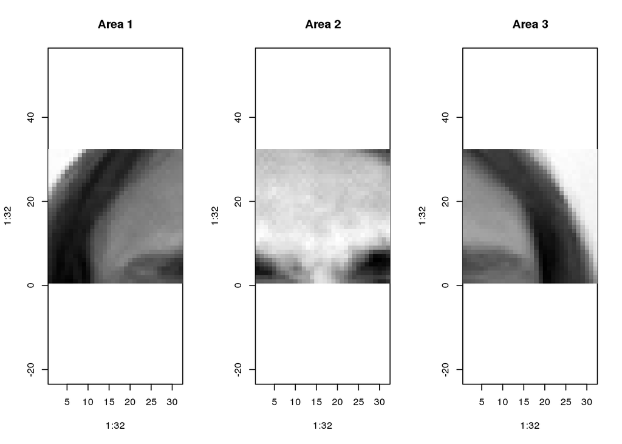

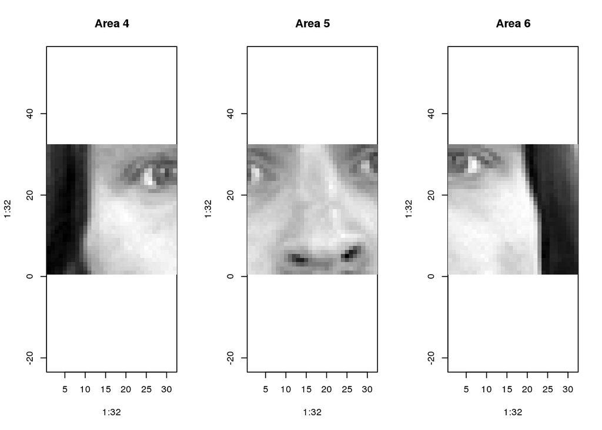

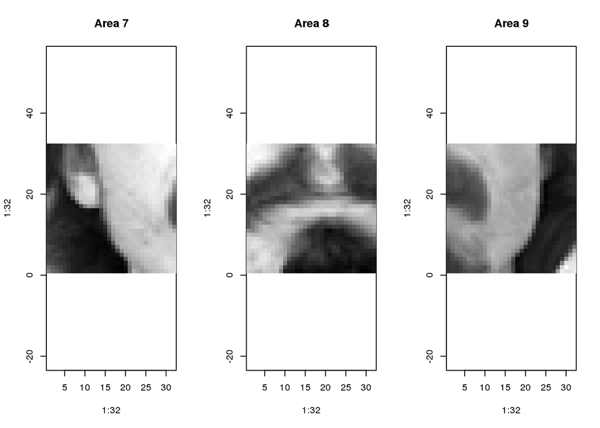

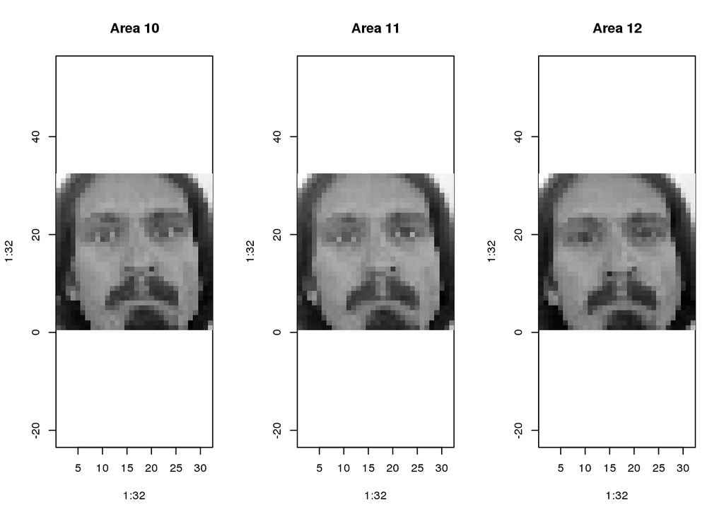

```r
i <- rev(im.train[1,])

par(mfrow = c(1,3))
for(a in 1:12){
  ii <- i[im.pca.area.idx[a,]]
  image(1:32,1:32,matrix(ii,nrow=32,ncol=32), col=gray((0:255)/255),asp=1.)
  title(main=paste("Area",a))
}
```

```r
rm(i,a)
```

Sounds good !

## Generating the PCA models for each area

We want to create a set of features, for each image, by agregating a selection of the PCA from each subimage. The models will be saved in a list **im.pca**, one model per area.

Remember to use double brackets **[[]]** to access individual list elements !

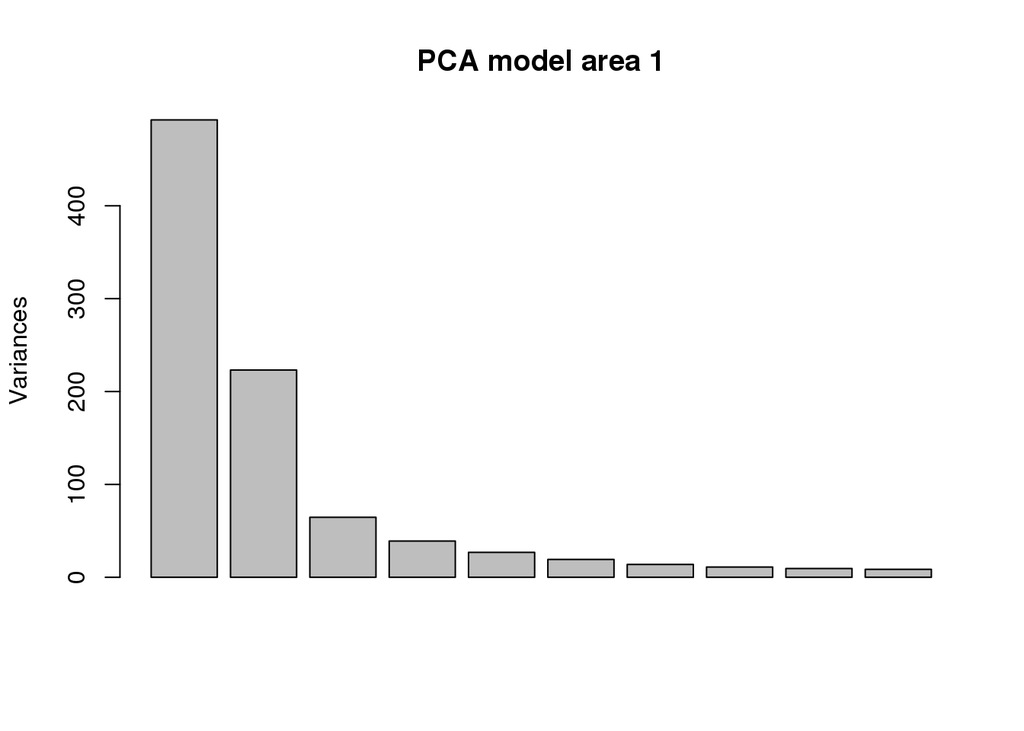

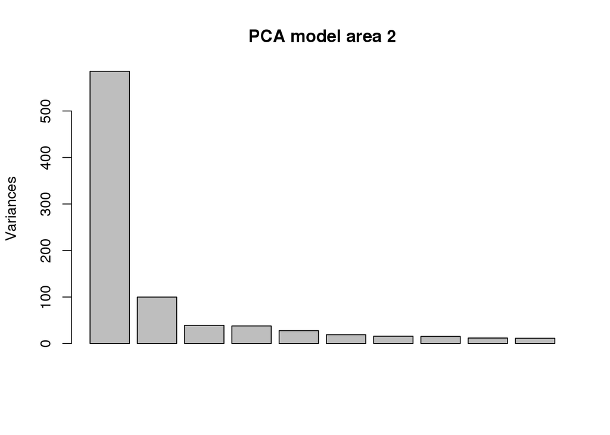

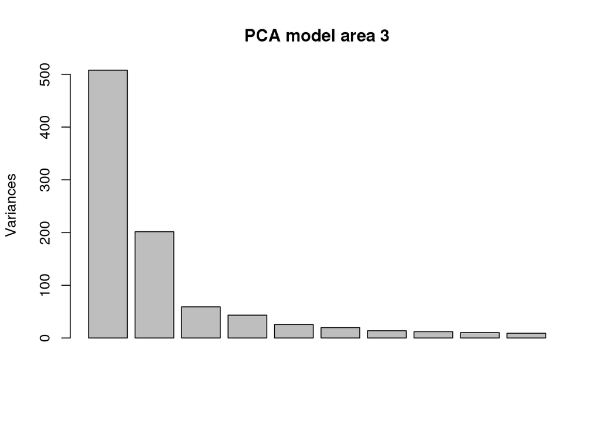

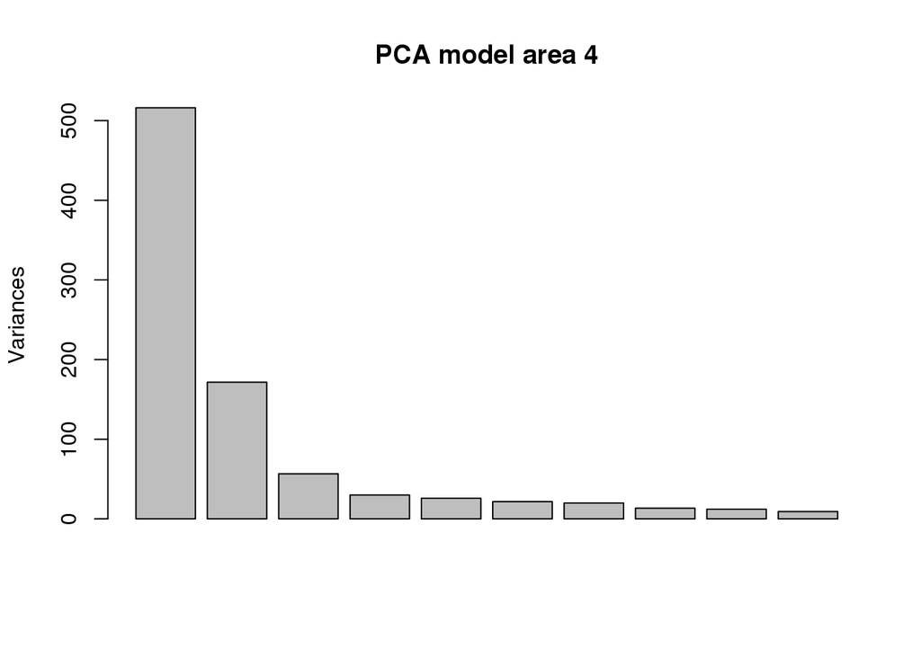

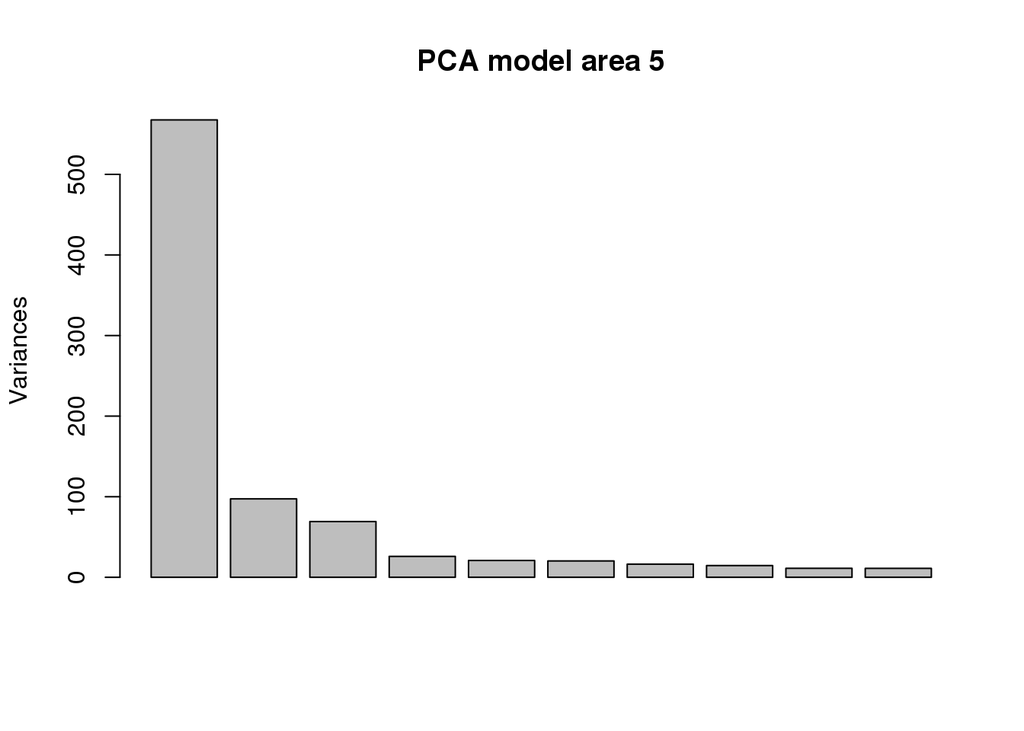

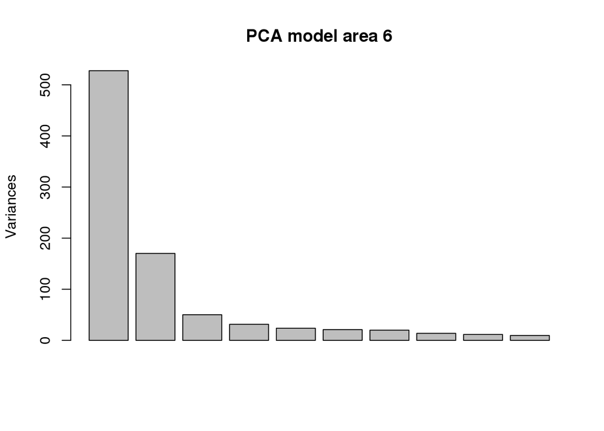

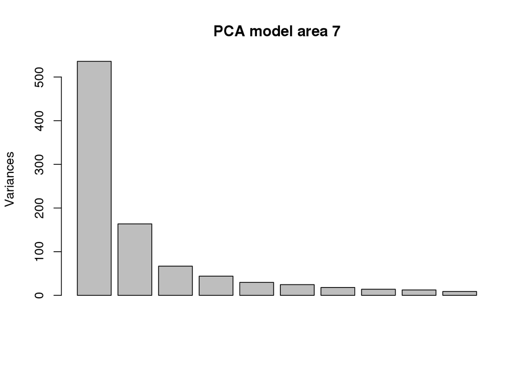

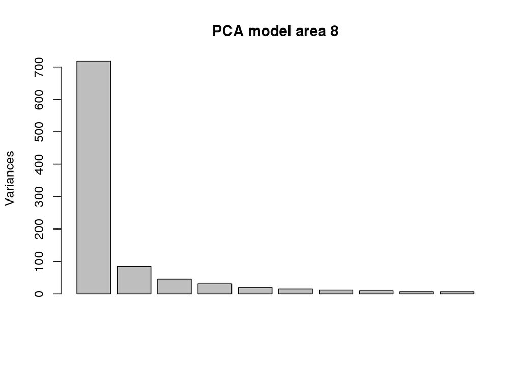

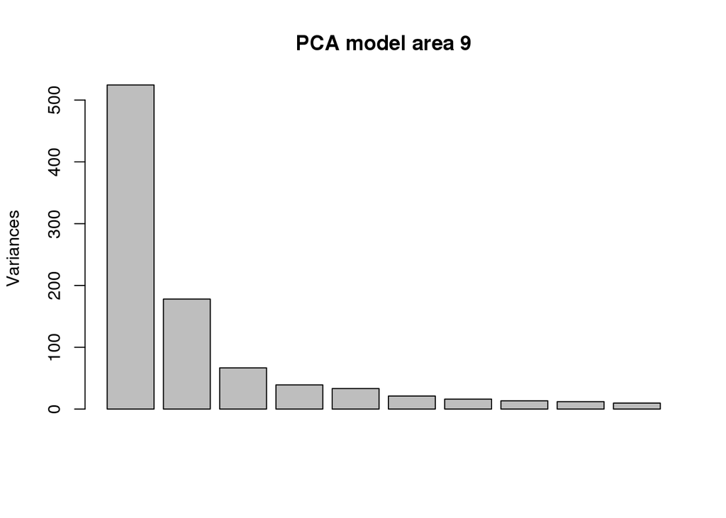

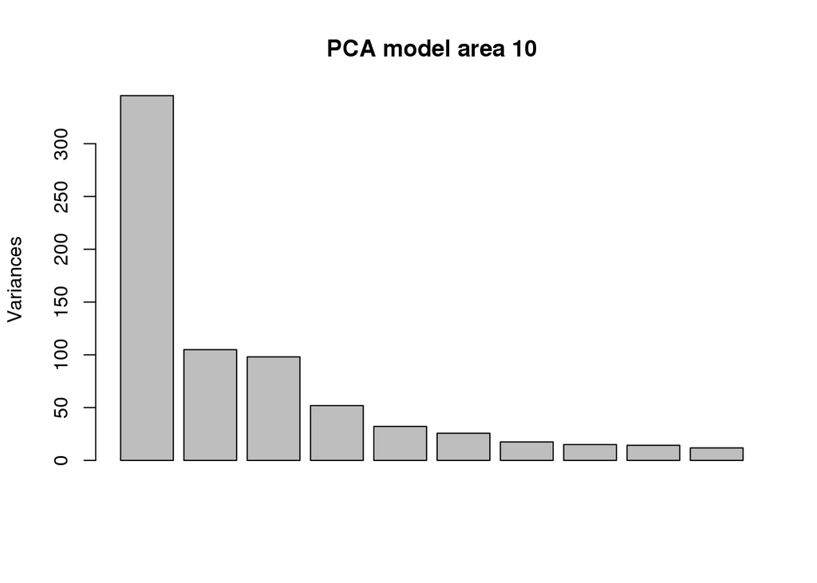

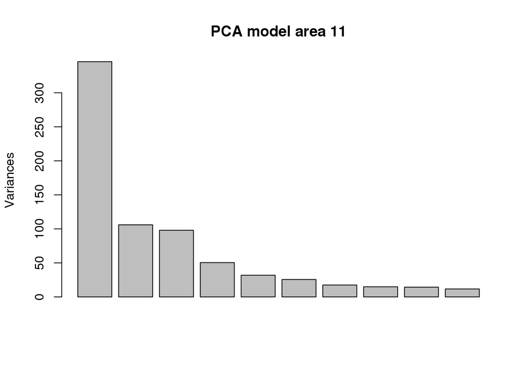

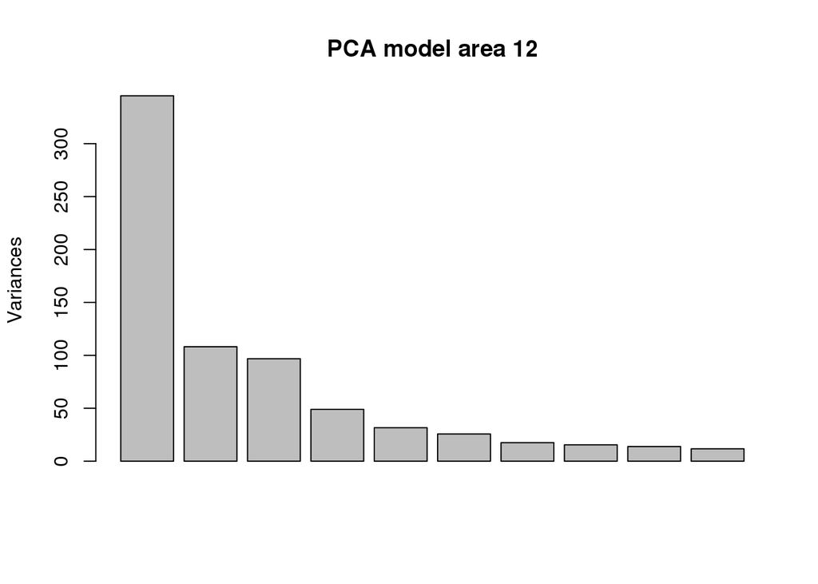

```r
par(mfrow = c(1,1))
im.pca <- list()
im.pca.dev <- matrix(0,nrow=0,ncol=50)
for(i in 1:12) {
  im.pca[[i]] <- prcomp(
    im.train[,im.pca.area.idx[i,]],
    scale. = TRUE,
    center=TRUE,
    retx = FALSE )
  plot(im.pca[[i]], main = paste("PCA model area",i))
  im.pca.dev <- rbind(im.pca.dev, im.pca[[i]]$sdev)  #Save for later plotting
}
```

```r
rm(i)
```

## Plotting the std deviations

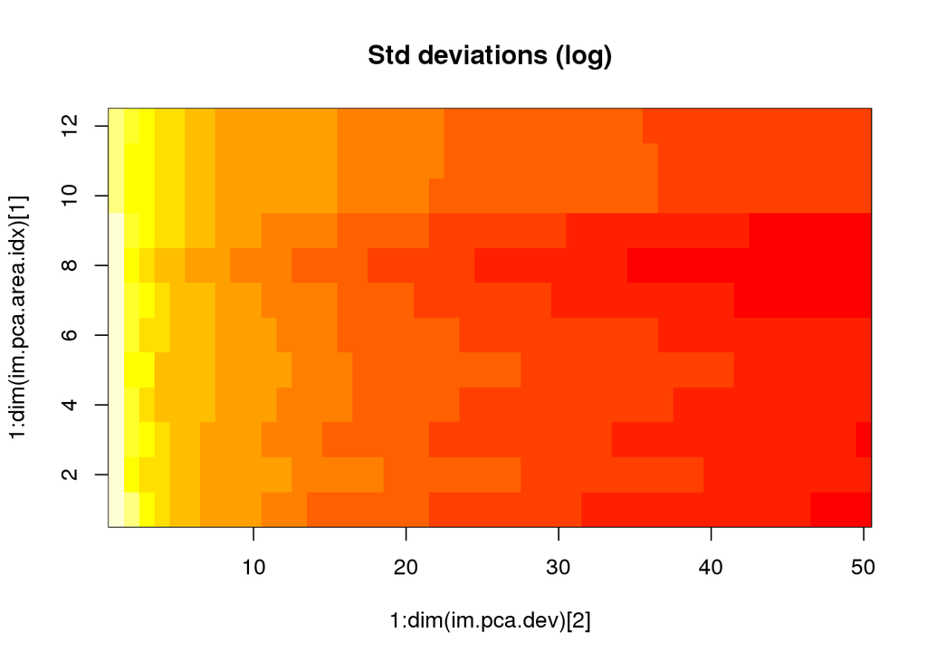

```r
par(mfrow=c(1,1))
image(1:dim(im.pca.dev)[2],1:dim(im.pca.area.idx)[1],log(t(im.pca.dev)))
title(main = "Std deviations (log)")
```

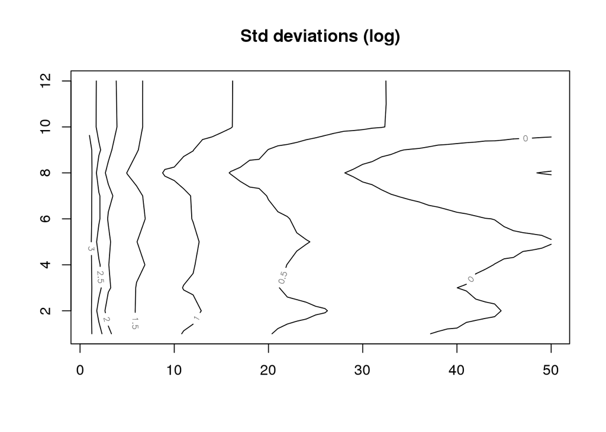

```r
contour(1:dim(im.pca.dev)[2],1:dim(im.pca.area.idx)[1],log(t(im.pca.dev)))
title(main = "Std deviations (log)")
```

## Generating the compressed images PCs

We define a function to process an entire inmage into a row of aggregated PCs. Image i is provided in a vector form.

```r
# i is a nx9216 matrix
# pc is a n x (12*10) vector

im.pca.predict <- function(i) {
  keep <- 10
  pc <-  matrix(0, nrow=nrow(i),ncol = nrow(im.pca.area.idx)*keep)
  for(a in 1:nrow(im.pca.area.idx)) {
    ## We keep "keep" PC per sub-image
    pc[,((a-1)*keep + 1):(a*keep)] <-
      predict(
        im.pca[[a]],
        newdata = i[,im.pca.area.idx[a,]]
        )[,1:keep]
  }
  return (pc)
}

##TEST

im.pca.predict(im.train[1:2,])
```

```
##           [,1]      [,2]      [,3]       [,4]      [,5]      [,6]
## [1,] -10.15139  -4.61761 15.673119  0.5262664  2.329845 -8.634738
## [2,]  18.16649 -37.33903  1.606529 11.5289362 -4.386188 12.970178
##            [,7]       [,8]      [,9]      [,10]      [,11]      [,12]
## [1,]  -3.693572 -0.1252328  3.479808 -0.2172294 -25.695124   7.285732
## [2,] -10.521679 11.0219865 -2.086022  2.9897830  -1.015488 -18.597125
##          [,13]      [,14]     [,15]       [,16]    [,17]      [,18]
## [1,]  4.289989 -0.3540651  4.108959 -0.02115115 3.571325 4.70710659
## [2,] -5.924186 -6.8310428 13.806345 -4.61003261 4.209049 0.05560255
##          [,19]     [,20]     [,21]       [,22]     [,23]    [,24]
## [1,] -5.201472  6.257846  9.224206 -14.7382805 -3.204696 4.970604
## [2,]  1.394060 -1.248157 42.290791   0.9598705 10.850863 6.945396
##          [,25]    [,26]     [,27]      [,28]     [,29]      [,30]
## [1,] -1.132713 0.280068 4.5844141 -2.9873903 -2.506064 -3.0669644
## [2,]  7.641029 6.171562 0.3662744  0.7520732  7.154615 -0.7911242
##           [,31]       [,32]     [,33]      [,34]      [,35]    [,36]
## [1,]   4.559896 12.73271194  6.405327 -0.2435227  -3.919994 1.308014
## [2,] -33.935101 -0.02214868 15.150828  2.7813032 -11.361988 2.883432
##           [,37]     [,38]    [,39]     [,40]      [,41]     [,42]
## [1,] -0.9988548  6.307149 4.008732 0.3498658 -0.4194767  -1.19868
## [2,] -9.4876330 -1.971830 7.641458 1.5668269 -3.1467889 -23.44210
##           [,43]     [,44]      [,45]      [,46]     [,47]      [,48]
## [1,] -0.9379228 -3.684175 -1.3196569 -0.9950387 -2.223154  0.3615502
## [2,]  7.5742142 -2.939870  0.4706019 -8.8228356 -2.315829 -2.2687286
##          [,49]    [,50]     [,51]     [,52]     [,53]     [,54]     [,55]
## [1,] -1.204691 3.211102  6.124876 13.206620 -6.985693  1.396061 -1.509293
## [2,] -6.999180 4.225876 29.935082  8.822333  5.834483 -2.080200 -9.182708
##          [,56]    [,57]      [,58]    [,59]     [,60]      [,61]
## [1,] -3.316558 3.641002  0.6016363 1.722053  2.613510  -4.265985
## [2,]  2.226613 1.132924 -1.6674086 1.605388 -4.111921 -36.074706
##           [,62]     [,63]     [,64]    [,65]     [,66]    [,67]    [,68]
## [1,] -21.486902 15.441237 -6.064249 -4.63951 -11.20155 -9.31699 3.607657
## [2,]  -3.933456 -8.431415 -5.370633 13.28905 -14.81271 -5.55976 4.469416
##          [,69]    [,70]      [,71]    [,72]     [,73]     [,74]      [,75]
## [1,]  2.595676 4.744158  -3.811961 4.061425 -3.175458  1.830006  2.3253022
## [2,] -3.314062 2.440547 -22.863711 9.117296  2.675997 -1.934613 -0.8477063
##           [,76]    [,77]       [,78]    [,79]     [,80]     [,81]
## [1,] 0.08562455 2.682583 -0.64399188 1.007944 -1.084581 -6.224692
## [2,] 3.55132081 4.997158 -0.04786537 2.594410 -0.285826 15.888895
##          [,82]     [,83]     [,84]     [,85]    [,86]     [,87]     [,88]
## [1,] 0.7372300 -4.982089 -3.174285 -5.291095 7.060264 -4.627652 -2.397794
## [2,] 0.7628079  3.947345 -8.323491  1.288085 3.821806 -0.177343 -3.357330
##          [,89]     [,90]    [,91]       [,92]     [,93]     [,94]
## [1,] -3.175680 -6.004956 4.706525   0.6481709 -1.344873 -5.850377
## [2,]  1.991368  4.968275 2.074745 -27.8197803 -6.002467 -2.956748
##          [,95]     [,96]    [,97]    [,98]     [,99]   [,100]   [,101]
## [1,]  5.033143 -7.498384 1.974891 5.825311 -1.360351 6.042842 4.945558
## [2,] 10.892636 -2.762014 4.789417 1.761702 -2.076173 4.489965 2.522492
##            [,102]    [,103]    [,104]    [,105]    [,106]   [,107]
## [1,]   0.05935318 -2.519435 -5.989988  4.819672 -6.649694 2.094405
## [2,] -28.15279567  2.987445 -3.062077 11.286346 -1.964909 4.461900
##        [,108]     [,109]   [,110]   [,111]     [,112]    [,113]   [,114]
## [1,] 3.160582 -4.1657196 4.775104 5.469819  0.7409673  3.539208 6.165697
## [2,] 3.856471  0.2960142 4.352425 2.841968 27.2412742 -8.420917 2.761107
##          [,115]   [,116]    [,117]   [,118]    [,119]    [,120]
## [1,]  -4.473276 5.733897 -1.597344 3.550920  3.005105 -2.623457
## [2,] -11.239974 1.268775 -3.791376 5.362439 -1.251036 -3.728169
```

## Computing the PC for the images

This new set of input variables will be stored in **im.pca.pcs**

```r
im.pca.pcs <- im.pca.predict(im.train)
```

## Cleaning and saving

We save what was creted

```r
save(im.pca.pcs, im.pca.predict, im.pca.area.idx, im.pca.makesubindex, file="im.pca.RData")
ls()
```

```
## [1] "ii"                  "im.pca"              "im.pca.area.idx"
## [4] "im.pca.dev"          "im.pca.makesubindex" "im.pca.pcs"
## [7] "im.pca.predict"      "im.train"
```

*This file was compiled on Mon Jun 6 08:06:25 2016*